# 13 Introducción a las Distribuciones de Probabilidad.

2024-04-23

## Análisis de datos I (MAT1409)

## 5 Introducción a las Distribuciones de Probabilidad.

## Tema 5.1: Objetivos de las Distribuciones de Probabilidad.

### ¿Qué son las Distribuciones de Probabilidad?

- Las distribuciones de probabilidad son funciones matemáticas que describen la probabilidad de diferentes valores posibles de una variable aleatoria.
- Se utilizan para modelar y comprender el comportamiento de eventos inciertos.

## Tema 5.1: Objetivos de las Distribuciones de Probabilidad.

### Objetivos:

1. **Comprender la variabilidad**: Las distribuciones de probabilidad nos ayudan a entender cómo los valores de una variable aleatoria pueden variar.
2. **Calcular probabilidades**: Nos permiten determinar la probabilidad de que ocurran ciertos eventos o resultados.
3. **Identificar patrones**: Al estudiar diferentes distribuciones, podemos identificar patrones y características específicas.

## Tema 5.2: Usos de las Distribuciones de Probabilidad.

### 1. Análisis Estadístico:

- Las distribuciones de probabilidad son fundamentales en el análisis estadístico.
- Nos ayudan a modelar datos y tomar decisiones basadas en la incertidumbre.

### 2. Evaluación de Riesgos:

- En campos como finanzas y seguros, las distribuciones de probabilidad se utilizan para evaluar riesgos y calcular pérdidas potenciales.

## Tema 5.2: Usos de las Distribuciones de Probabilidad.

### 3. Toma de Decisiones:

- Al comprender las probabilidades asociadas con diferentes escenarios, podemos tomar decisiones informadas.

### 4. Modelado Financiero:

- Las distribuciones de probabilidad se aplican en la valoración de activos financieros y en la predicción de rendimientos.

## Tema 5.3: Características de las Distribuciones de Probabilidad.

### 2. Función de Densidad o Masa:

- Puede ser discreto (conjunto contable de valores) o continuo (intervalo de valores medible).
- La función de densidad de probabilidad (PDF) para variables continuas o función de masa de probabilidad (PMF) describe la probabilidad para variables discretas.

## Tema 5.4: Momentos de las Distribuciones de Probabilidad.

- Los momentos son medidas cuantitativas que describen características de una distribución.
- **Primer Momento (Media o Valor Esperado)**: Representa el promedio ponderado de todos los posibles valores que puede tomar la variable aleatoria.
- **Segundo Momento (Varianza)**: Mide la dispersión de los valores alrededor de la media.

## Tema 5.4: Momentos de las Distribuciones de Probabilidad.

- **Tercer Momento (Asimetría o Skewness)**: Indica la simetría de la distribución. Una distribución con asimetría positiva tiene una cola más larga hacia la derecha; si es negativa, la cola es más larga hacia la izquierda.
- **Cuarto Momento (Curtosis)**: Mide la “gordura” de las colas de la distribución. Una curtosis alta indica colas más pesadas y una mayor presencia de valores atípicos en las colas.

## Tema 5.4: Momentos de las Distribuciones de Probabilidad.

Curtosis:

| Tipo de Distribución | Interpretación de Curtosis | Rango Aceptable (en valor absoluto) |
| --- | --- | --- |
| **Distribución Mesocúrtica** (Kurtosis ≈ 0) | Colas similares a una distribución normal (con forma de campana). | \(\| \text{Curtosis} \| < 2\) |
| **Distribución Leptocúrtica** (Kurtosis positiva) | Colas más pesadas que una distribución normal. | \(\| \text{Curtosis} \| > 2\) |
| **Distribución Platicúrtica** (Kurtosis negativa) | Colas más ligeras que una distribución normal. Valores más cercanos a la media. | \(\| \text{Curtosis} \| > 2\) |

## 5.5 Distribución Uniforme.

- La distribución uniforme describe un escenario donde todos los resultados posibles tienen la misma probabilidad de ocurrir.
- Ejemplo clásico: Lanzamiento de un dado justo.
- La PMF de una variable aleatoria (X) con distribución uniforme discreta en el conjunto \(S = {x_1, x_2, \ldots, x_n}\) es:

\[ P(X = x_i) = \frac{1}{n} \quad \text{para } i = 1, 2, \ldots, n \]

## 5.5 Distribución Uniforme, ejemplos.

- Si \(X\) es una variable aleatoria que representa el resultado de lanzar un dado, entonces \(X\) tiene una distribución uniforme discreta con probabilidad \(P(X=x) = \frac{1}{6}\) para \(x = 1, 2, 3, 4, 5, 6\).
- Si \(X\) es una variable aleatoria que representa la ocupación de una mesa en un restaurante. \(P(X=x) = \frac{1}{10}\) para \(x = 1, 2, \dots, 10\).
- Si \(X\) es una variable aleatoria que representa la venta de un modelo de arete con tres tipos de colores.\(P(X=x) = \frac{1}{3}\) para \(x = Azul, Verde, Rojo\).

## 5.5 Distribución Uniforme, Plot.

- Tirar un dado 100 veces.

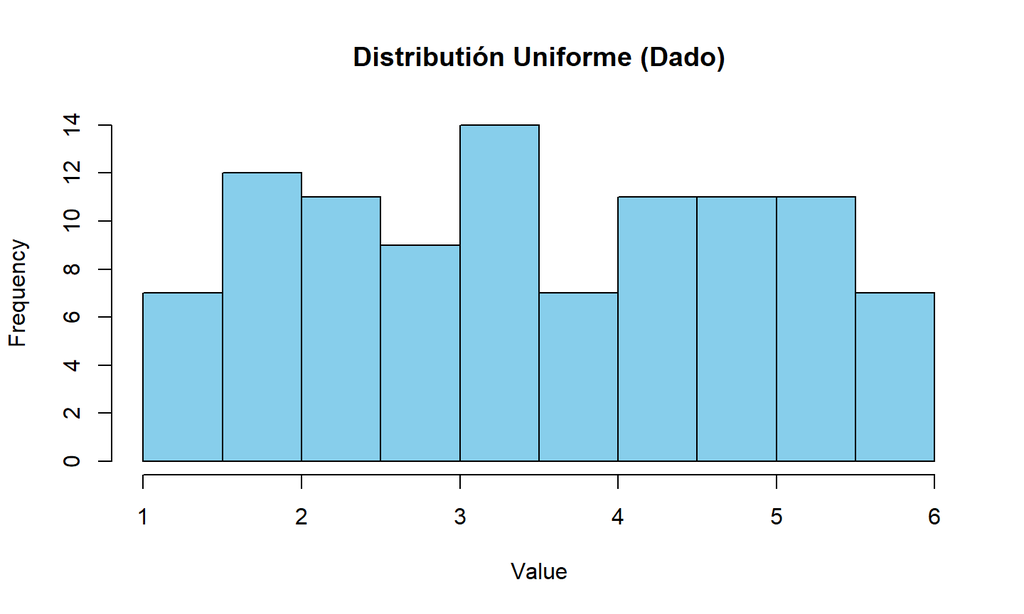

## 5.5 Momentos de la Distribución Uniforme Discreta.

Valor Esperado (Media): \(E(X) = \frac{1}{n} \sum_{i=1}^{n} x_i\)

Varianza: \(Var(X) = \frac{1}{n} \sum_{i=1}^{n} (x_i - E(X))^2\)

Asimetría o Sesgo (Skewness): \(γ = E[(X - µ)^3] / σ^3\)

Kurtosis: \(κ = E[(X - µ)^4] / σ^4 - 3\)

## 5.5 Momentos de la Distribución Uniforme Discreta.

- Cálculo de la Curtosis para un Dado Justo de Seis Caras
1. **Media (\(\mu\))**: La media de un dado justo de seis caras es el promedio de todos los resultados posibles:

   \[ \mu = \frac{1 + 2 + 3 + 4 + 5 + 6}{6} = 3.5 \]
2. **Cuarto Momento Central (\(\mu_4\))**: El cuarto momento central para una distribución uniforme discreta es:

   \[ \mu_4 = \frac{1}{n} \sum_{i=1}^{n} (x_i - \mu)^4 = = 14.72917\]

## 5.5 Momentos de la Distribución Uniforme Discreta.

1. **Varianza (\(\sigma^2\))**: La varianza para un dado justo de seis caras es:

   \[ \sigma^2 = \frac{1}{6} \sum_{i=1}^{6} (x_i - 3.5)^2=2.9166 \]

## 5.5 Momentos de la Distribución Uniforme Discreta.

1. **Exceso de Curtosis**: El exceso de curtosis se calcula utilizando:

   \[ \text{Exceso de Curtosis} = \frac{\mu_4}{\sigma^4} - 3 \]

   Sustituyendo los valores que tenemos:

   \[ \text{Exceso de Curtosis} = \frac{14.73}{\left(2.9166\right)^2} - 3 \]

```
## [1] -1.268571
```

## 5.6 Distribución Binomial

1. **Definición**:
   - La distribución binomial modela el número de éxitos en una secuencia de \(n\) ensayos independientes, donde cada ensayo tiene dos posibles resultados: éxito o fracaso.
   - Ejemplo: Lanzamiento de una moneda justa (cara o cruz).

## 5.6 Distribución Binomial

1. **Función de Masa de Probabilidad (PMF)**:
   - Para una variable aleatoria \(X\) con distribución binomial, la PMF es: \[ P(X = k) = \frac{n!}{k!(n-k)!} p^k (1-p)^{n-k} \] donde:
     - \(n\) es el número total de ensayos.
     - \(k\) es el número de éxitos.
     - \(p\) es la probabilidad de éxito en un solo ensayo.

## 5.6 Ejemplos de Distribución Binomial

Supongamos que una empresa de comercio electrónico está llevando a cabo una campaña de marketing por correo electrónico para promocionar un nuevo producto. La tasa de conversión estimada (probabilidad de que un destinatario realice una compra después de recibir el correo) es del 5%. La empresa planea enviar el correo a 2000 destinatarios. ¿Cual es la probabilidad de que exactamente 50 hagan la compra?

## 5.6 Ejemplos de Distribución Binomial, Plot

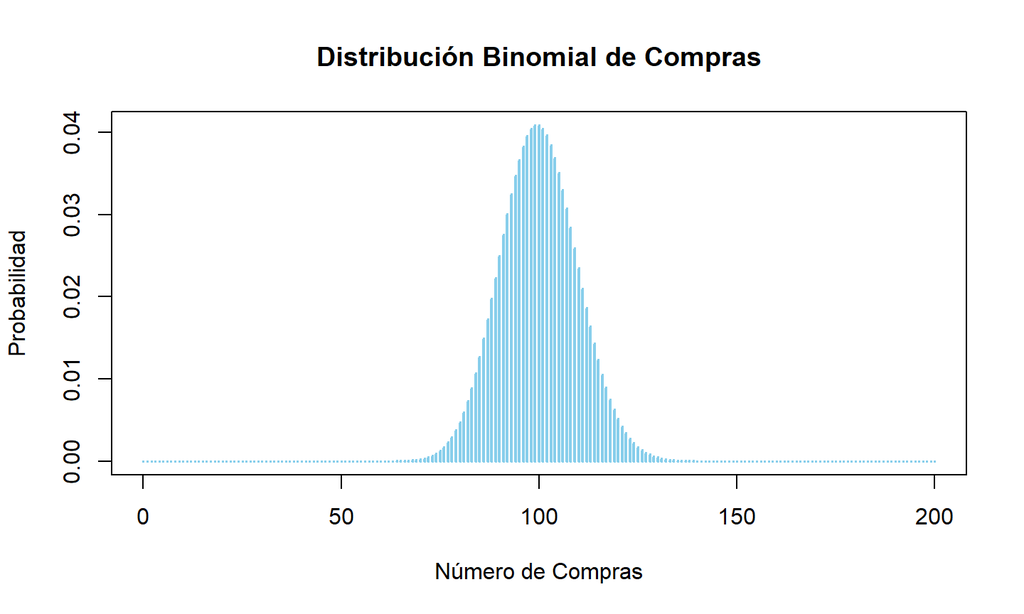

## 5.6 Momentos de la Distribución Binomial

1. **Valor Esperado (Media)**:

   \[ E(X) = np \] Donde \(n\) es el número de ensayos (usuarios) y \(p\) es la probabilidad de éxito (tasa de clics).
2. **Varianza**:

   \[ Var(X) = np(1-p) \]

## 5.6 Momentos de la Distribución Binomial

1. **Asimetría (Skewness)**:

   \[ \text{Skewness} = \frac{1 - 2p}{\sqrt{np(1-p)}} \]
2. **Curtosis**:

   \[ \text{Curtosis} = \frac{1 - 6p(1-p)}{np(1-p)} \]

## 5.6 Momentos de la Distribución Binomial, ejemplo

En un escenario de negocios, supongamos que una empresa lanza una nueva campaña publicitaria en línea. La campaña tiene una tasa de clics del 10%. Cada vez que se muestra un anuncio, hay una probabilidad del 10% de que un usuario haga clic en él. La empresa planea mostrar el anuncio a \(n = 1000\) usuarios.

```
## Valor Esperado (Media): 100
```

```
## Varianza: 90
```

```
## Asimetría (Skewness): 0.0843274
```

```
## Curtosis: 0.005111111
```

## 5.6 Momentos de la Distribución Binomial, Ejercicios:

### Ejercicio 1: Tienda en Línea de Ropa

Número de Eventos: Una tienda en línea de ropa envía correos electrónicos promocionales a 5000 clientes.

Probabilidad de Éxito: La probabilidad de que un cliente realice una compra después de recibir el correo es del 8%.

### Combinaciones de Éxitos

1. **¿Cuántos clientes se espera que realicen una compra? (Valor esperado)**

   Utilizando la fórmula de la media de la distribución binomial: \[ E(X) = np \] \[ E(X) = 5000 \times 0.08 = 400 \]

## 5.6 Momentos de la Distribución Binomial, Ejercicios:

1. **¿Cuál es la probabilidad de que exactamente 200 clientes realicen una compra?**

   Utilizando la fórmula de la PMF de la distribución binomial: \[ P(X = k) = \binom{n}{k} p^k (1-p)^{n-k} \] \[ P(X = 200) = \binom{5000}{200} (0.08)^{200} (0.92)^{4800} \]

## 5.6 Momentos de la Distribución Binomial, Ejercicios:

### Ejercicio 2: Lanzamiento de un Nuevo Producto

Número de Eventos: Una empresa lanza un nuevo producto y envía muestras a 100 minoristas.

Probabilidad de Éxito: La probabilidad de que un minorista decida vender el producto es del 20%.

### Combinaciones de Éxitos

1. **¿Cuántos minoristas se espera que vendan el producto? (Valor esperado)**

   Utilizando la fórmula de la media de la distribución binomial: \[ E(X) = np \] \[ E(X) = 100 \times 0.20 = 20 \]

## 5.6 Momentos de la Distribución Binomial, Ejercicios:

1. **¿Cuál es la probabilidad de que exactamente 25 minoristas vendan el producto?**

   Utilizando la fórmula de la PMF de la distribución binomial: \[ P(X = k) = \binom{n}{k} p^k (1-p)^{n-k} \] \[ P(X = 25) = \binom{100}{25} (0.20)^{25} (0.80)^{75} \]

## Ejercicio 3: Encuesta de Satisfacción del Cliente

Número de Eventos: Una empresa realiza una encuesta de satisfacción del cliente y envía cuestionarios a 300 clientes.

Probabilidad de Éxito: La probabilidad de que un cliente complete y devuelva el cuestionario es del 15%.

### Combinaciones de Éxitos

1. **¿Cuántos clientes se espera que completen y devuelvan el cuestionario? (Valor esperado)**

   Utilizando la fórmula de la media de la distribución binomial: \[ E(X) = np \] \[ E(X) = 300 \times 0.15 = 45 \]

## 5.6 Momentos de la Distribución Binomial, Ejercicios:

1. **¿Cuál es la probabilidad de que exactamente 40 clientes completen y devuelvan el cuestionario?**

   Utilizando la fórmula de la PMF de la distribución binomial: \[ P(X = k) = \binom{n}{k} p^k (1-p)^{n-k} \] \[ P(X = 40) = \binom{300}{40} (0.15)^{40} (0.85)^{260} \]

## 5.6 Momentos de la Distribución Binomial, Ejercicios:

1. **¿Cuál es la probabilidad de que menos de 3 clientes completen y devuelvan el cuestionario?**

## 5.7 Distribución de Poisson

1. **Definición**:
   - La distribución de Poisson modela el número de eventos raros en un intervalo de tiempo o espacio específico.
   - Ejemplo: Número de llamadas recibidas en un centro de atención telefónica en una hora.

## 5.7 Distribución de Poisson

1. **Función de Masa de Probabilidad (PMF)**:
   - Para una variable aleatoria \(X\) con distribución de Poisson, la PMF es: \[ P(X = k) = \frac{{e^{-\lambda} \lambda^k}}{{k!}} \] donde:
     - \(k\) es el número de eventos.
     - \(\lambda\) es el parámetro de intensidad (número esperado de eventos en el intervalo).

## 5.7 Ejemplos de Distribución de Poisson

Supongamos que un restaurante de comida rápida recibe un promedio de 2 pedidos de entrega por hora durante las horas de almuerzo. ¿Cuál es la probabilidad de que el restaurante reciba exactamente 3 pedidos durante la próxima hora?

## 5.7 Ejemplos de Distribución de Poisson, Plot

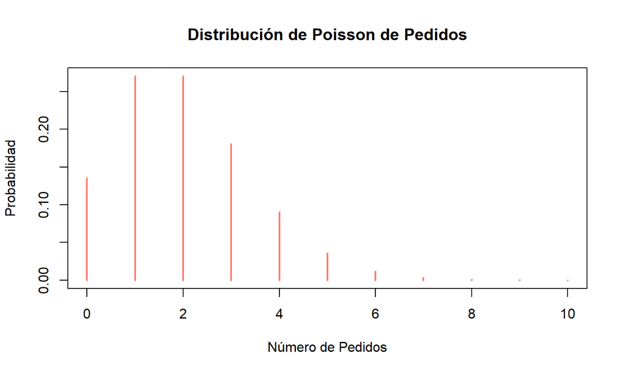

## 5.7 Momentos de la Distribución de Poisson

1. **Valor Esperado (Media)**: \[ E(X) = \lambda \]
2. **Varianza**: \[ Var(X) = \lambda \]
3. **Asimetría (Skewness)**: \[ \text{Skewness} = \frac{1}{\sqrt{\lambda}} \]

## 5.7 Momentos de la Distribución de Poisson

1. **Curtosis**: \[ \text{Curtosis} = \frac{1}{\lambda} \]

## 5.8 Distribución Normal (Gaussiana)

La distribución normal, también conocida como distribución gaussiana, es una de las distribuciones más importantes en estadística. Se caracteriza por su forma de campana y se utiliza ampliamente en modelado y análisis de datos.

## 5.8 Momentos de la Distribución Normal

### Media (µ)

\[ µ = E(X) = \frac{1}{n} \sum_{i=1}^{n} x_i \]

### Varianza (σ^2)

\[ σ^2 = Var(X) = E[(X - µ)^2]= \frac{1}{n} \sum_{i=1}^{n} (x_i - E(X))^2 \]

## 5.8 Momentos de la Distribución Normal

### Sesgo (γ)

\[γ = E[(X - µ)^3] / σ^3\]

### Kurtosis (k)

\[κ = E[(X - µ)^4] / σ^4 - 3\]

## 5.8 Distribución Normal Estándar (Z-Score)

La **distribución normal estándar**, también conocida como **distribución gaussiana estándar**, es una versión especial de la distribución normal con una media (\(\mu\)) de 0 y una desviación estándar (\(\sigma\)) de 1. Se denota como \(Z \sim N(0, 1)\).

## 5.8 Distribución Normal Estándar (Z-Score)

### Características de la Distribución Normal Estándar

- **Media (\(\mu\))**: 0
- **Desviación Estándar (\(\sigma\))**: 1
- **Función de Densidad de Probabilidad (PDF)**:

\[ f(z) = \frac{1}{\sqrt{2\pi}} e^{-\frac{z^2}{2}} \]

## 5.8 Distribución Normal Estándar (Z-Score)

### ¿Qué es el Z-Score?

El **Z-score** (o puntaje Z) es una medida estandarizada que indica cuántas desviaciones estándar un valor dado se encuentra por encima o por debajo de la media en una distribución normal estándar. Es útil para comparar valores en diferentes escalas y comprender su posición relativa en la distribución.

### Cálculo del Z-Score

Para calcular el Z-score de un valor \(x\) en una distribución normal con media \(\mu\) y desviación estándar \(\sigma\):

\[ Z = \frac{x - \mu}{\sigma} \]

## 5.8 Distribución Normal Estándar (Z-Score)

### Uso del Z-Score

1. **Identificación de Valores Atípicos**:
   - Valores con Z-scores muy altos o muy bajos pueden considerarse atípicos o inusuales.
2. **Cálculo de Probabilidades**:
   - El Z-score se utiliza para encontrar probabilidades acumuladas en la tabla Z.
   - Por ejemplo, \(P(Z < z)\) representa la probabilidad de que un valor sea menor que \(z\).
3. **Comparación de Datos**:
   - Permite comparar valores en diferentes distribuciones normalizándolos.

## 5.8 Distribución Normal Estándar: Ejemplo (1/1)

Asumiendo que la distribución del IQ sigue una distribución normal, te embarcas en la tarea de calcular la probabilidad de seleccionar un estudiante al azar cuyo IQ se encuentre entre 110 y 120, si conoces que la deviación estándar es de 15 puntos y al media es 100 puntos.

\[ P( 110 < X < 120) = ? \]

## 5.8 Distribución Normal Estándar: Ejemplo (2/1)

### Paso 1: Los valores del z-score son los siguientes:

- \(z_1\)

```r
(110-100)/15
```

```
## [1] 0.6666667
```

- \(z_2\)

```r
(120-100)/15
```

```
## [1] 1.333333
```

## 5.8 Distribución Normal Estándar: Ejemplo (3/1)

### Paso 2: Graficar la region de probabilidad:

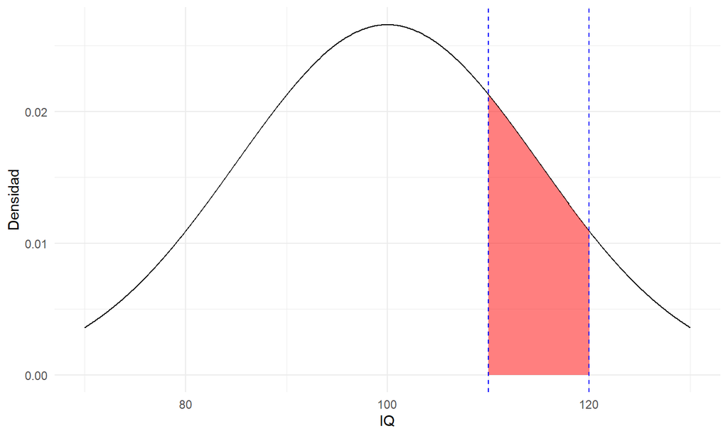

## 5.8 Distribución Normal Estándar: Ejemplo (3/1)

### Paso 3: Usar una tabla de probabilidad de la distribución normal (z-score) para entrontar la probabilidad.

- Típicamente, trabajamos con una tabla de cola derecha (right-tail).
- Lo que significa que el valor de z en tabla nos va proporcional la proababilidad acumulada desde ese valor de z hasta el final de la distribución.
- Por ejemplo para \(z_1=0.6666667\)
- La correspondiente probabilidad en tabla:

## 5.8 Distribución Normal Estándar: Ejemplo (4/1)

- Por convenciencia podemos redondear a dos decimales, \(z_1=0.67\), y en tabla, buscamos la columns \(0.07\):

Probabilidades para z-score de 110

|  | 0.00 | 0.01 | 0.02 | 0.03 | 0.04 | 0.05 | 0.06 | 0.07 | 0.08 | 0.09 |
| --- | --- | --- | --- | --- | --- | --- | --- | --- | --- | --- |
| 0.60 | 0.2743 | 0.2709 | 0.2676 | 0.2643 | 0.2611 | 0.2578 | 0.2546 | 0.2514 | 0.2483 | 0.2451 |

## 5.8 Distribución Normal Estándar: Ejemplo (5/1)

- Esta probabilidad es la siguiente en la gráfica:

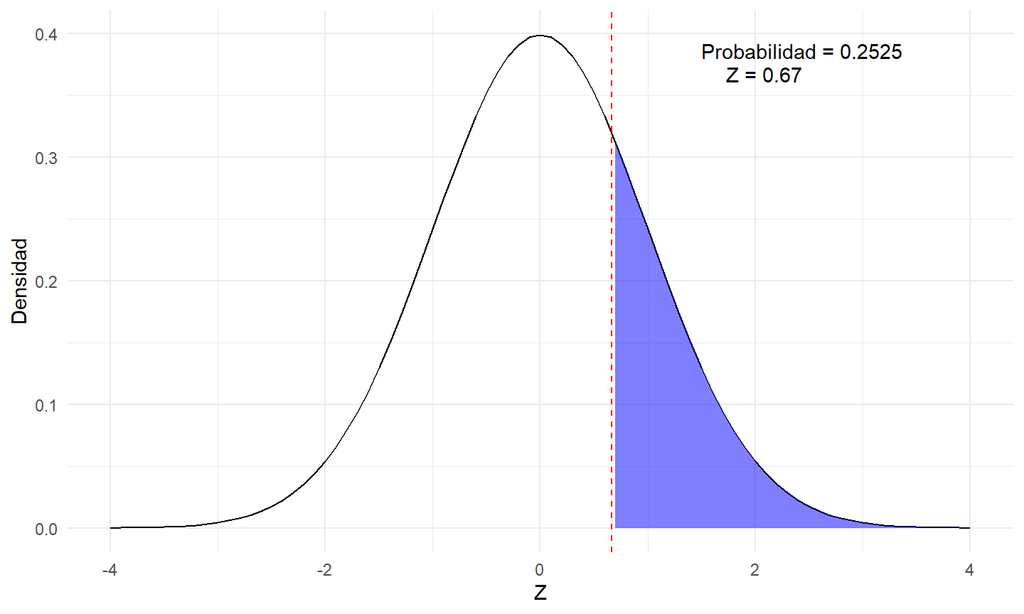

## 5.8 Distribución Normal Estándar: Ejemplo (6/1)

- Ahora buscamos el la probabilidad de \(z_2=1.33\) en la tabla:

Probabilidades para z-score de 120

|  | 0.00 | 0.01 | 0.02 | 0.03 | 0.04 | 0.05 | 0.06 | 0.07 | 0.08 | 0.09 |
| --- | --- | --- | --- | --- | --- | --- | --- | --- | --- | --- |
| 1.30 | 0.0968 | 0.0951 | 0.0934 | 0.0918 | 0.0901 | 0.0885 | 0.0869 | 0.0853 | 0.0838 | 0.0823 |

- Entonces: \[P(X>120)=P(Z>1.33)=0.0918\]

## 5.8 Distribución Normal Estándar: Ejemplo (7/1)

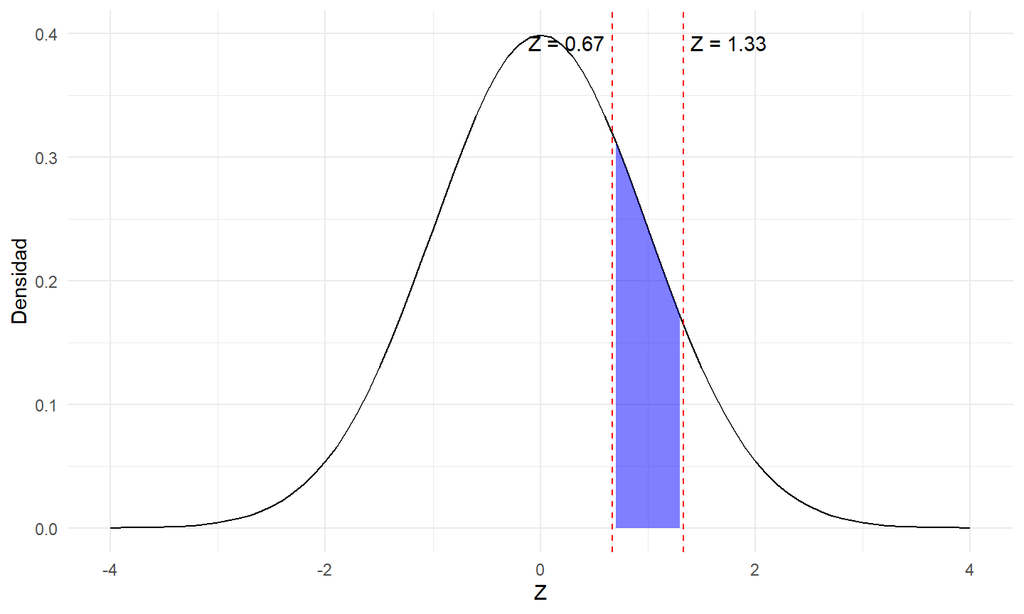

## Revisión

```
## Versión: 29/04/2024
```

## Bibliografía

- Dodge, Y. (2008). The concise encyclopedia of statistics. Springer Science & Business Media.
- Business Mathematics.(2023).SBPD https://www.google.com.mx/books/edition/Business_Mathematics/oRLFEAAAQBAJ
- Smith, G. (2015). *Essential statistics, regression, and econometrics.*
- Spiegel, M. R., Srinivasan, R. A., & Schiller, J. J. (2000). Schaum’s outline of theory and problems of probability and statistics. Erlangga.